# IISE and DSI Learn R

Tyler Richards

2017-11-28

This workshop was completed on 11/28/17 and was created with a beginner in mind. The following is a .rmd file of the code that was run in the workshop, primarily for individuals who may have missed something in the workshop itself or just want to go over the information again. As I did the majority of this live, there may be errors/more efficient way of doing things. If you see those, reach out at tylerjrichards@gmail.com and I will be happy to edit!

R is a data science specific langauge with a huge community of dedicated and helpful users in every field imaginable. Not only do Google, Microsoft, Uber, TechCrunch, P&G, the New York Times, and Bank of America use R, but also the best academic institutions in the world in every deparment from journalism to finance to political science and biology.

R allows for reproducible results!! This means that every change you make to your data is not only reversable, but it is repeatable for your project partners or coworkers. This is incredibly important for research and for communicating validity of results. If someone doesn’t believe your results, you can always send them your code and data and they can validate for themselves.

The goal of this workshop is to give you a foundation in R so that you can 1. read and understand code 2. start to write it yourself

We’ll start with R and R studio and explain the console, scripts, environment files, plots, and packages and then we’ll move into basic structure for modeling, cleaning, and working with your data.

Data Types:

```r
#numeric
x <- 3.7
#integer
y <- 5
#character
z <- "dog"
#boolean
a <- TRUE
b <- T
```

Vectors

```r
a<-c(1,2,3,4,5,6,7)
b<-c("one","two","three")   # or character vector

c<-c(TRUE,FALSE,FALSE,TRUE)  # or logical vector

a[1]
a[2:5]
a[-1]
a[-(1:3)]
a[-length(a)]
```

Matrix

```r
my_mat <-matrix(1:20,
                    nrow=5,
                    ncol=4)

mat <- matrix(c(1,77,56,33,22,43), nrow = 2, ncol = 3, byrow = TRUE)
```

Dataframe

```r
studentID <- c(1, 2, 3, 4)
age <- c(25, 19, 22, 21)
university <- c("UF", "FSU", "UF", "UGA")
hired <- c(TRUE, FALSE, TRUE, FALSE)
studentdata <- data.frame(studentID, age, university, hired)

studentdata[1,3]
studentdata[1,"hired"]
studentdata$age
```

How to be statistically savvy in R/useful functions to know. If you don’t understand an individual function, use help() and ?function for assistance.

```r
library(ISLR)
library(datasets)
library(dplyr)
```

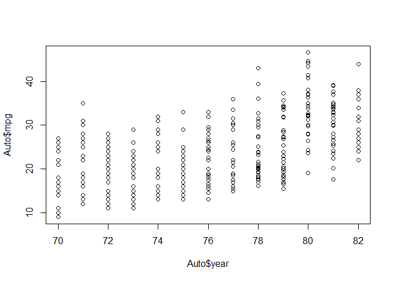

```r
#str gets the structure of the data
str(x)

#summary tells you more about the data
summary(x)
summary(Auto)

#head is the first 6 rows in a dataframe
head(Auto)

#plot creates a graph given x and y
plot(Auto$year, Auto$mpg)
```

```r
#column names
colnames(Auto)

#now some basic stats functions
#rnorm gives random numbers in a normal distribution
#cor.test is correlation test
#cumsum is cumulative sum
#sd is standard deviation

x = rnorm(100)
y = rnorm(100)
cor.test(x,y)
cumsum(x)
sd(x)
```

after that, we need to understand how to manipulate data. Best advice here is through dplyr, a library known as the grammar of data manipulation.

```r
library(dplyr)
head(airquality)

#dplyr runs off of specific verbs, here is filter

filter(airquality, Wind > 5)
filter(airquality, Temp > 80 & Month > 5)

#mutate makes a new column

mutate(airquality, TempInC = (Temp - 32) * 5 / 9)

#summarise aggregates data

summarise(airquality, mean(Temp, na.rm = TRUE))

#specify the columns you want with select

select(airquality, Temp)
select(airquality, -Temp)

#pipes allow you to string dplyr together
#group by creates a row for each unique value in a column and summarises as specified
airquality %>%
  filter(Month != 5) %>%
  mutate(TempInc = (Temp - 32) * 5 / 9)

airquality %>%
    filter(Month != 5) %>%
    group_by(Month) %>%
    summarise(mean(Temp, na.rm = TRUE))

airquality %>%
    filter(Month != 5) %>%
    group_by(Month) %>%
    summarise(mean(Temp, na.rm = TRUE))

select(airquality, Temp)
```

How to do basic modeling in R

```r
lin_reg <- lm(data = Auto, mpg ~ cylinders + displacement + horsepower + weight + acceleration + year)

summary(lin_reg)


predict(lin_reg, data.frame(cylinders = 8, displacement = 315, horsepower = 180, weight = 3445, acceleration = 11.0, year = 70))

predict(lin_reg, data.frame(cylinders = 8, displacement = 315, horsepower = 180, weight = 3445, acceleration = 11.0, year = 70))
#change year, acceleration, etc to see what is predicted

#this works the same for other types of models
```

That’s it! As usual, reach out with questions/opinions